# Association Study with lazyGas

Institute of Plant Science and Resources, Okayama University, Okayama, Japan

f.tomoyuki@okayama-u.ac.jp

Apr 4, 2025

#### Package

lazyGas 0.3.4

## 1 Introduction

This vignette demonstrates the process of conducting a genetic association study using the `lazyGas` package. We will go through the steps of loading input files, preprocessing data, performing association analysis, and visualizing results.

Load the lazyGas package.

```r
library(lazyGas)
```

## 2 Loading Input GDS file and Building a LazyGas Object

The lazyGas package was primarily designed to take as input a GDS file created using the *GBScleanR* package. If you have a VCF file for regression analysis, you can convert it to a GDS file using the gbsrVCF2GDS() function in GBScleanR.  
Load a sample GDS file and build a `LazyGas` class object.

```r
gds_fn <- system.file("extdata", "sample.gds", package = "lazyGas")
lg <- buildLazyGas(gds_fn = gds_fn, load_filter = TRUE, overwrite = FALSE)
```

If you applied filtering on markers and/or samples using the functions in the *GBScleanR* package, please set `load_filter = TRUE` that apply the same filters on the given data during building a `LazyGas` class object. The setting `overwrite = FALSE` ensures that all outputs stored in the input GDS file, which were created by functions in the `lazyGas` package, are preserved as they are. If `overwrite = TRUE`, those outputs will be removed. This setting has no effect when creating a `LazyGas` class object for the first time, but it does apply when reloading the GDS file for reanalysis.

If you have genotype information that are not stored in a GDS file, you can build a `LazyGas` class object by supplying a named list including the necessary information to the `create_gds` argument of the `buildLazyGas()` function.

```r
# Set a temporary file path for a GDS file.
temp_dir <- tempdir()
sample_gds <- tempfile("sample", temp_dir, ".gds")

# Now we assume genotype and marker data were provided as a matrix or
# data.frame that have been loaded from CSV files, although here we use data
# obtained from the GDS file for ease of handling as example usage.
genotype <- getGenotype(object = lg, node = "raw")
dosage <- getGenotype(object = lg, node = "dosage")
haplotype <- getHaplotype(object = lg)
snp.chromosome <- getChromosome(object = lg)
snp.position <- getPosition(object = lg)
snp.allele <- getAllele(object = lg)
sample.id <- getSamID(object = lg)
snp.id <- getMarID(object = lg)

# The following values can be NULL: snp.id, snp.rs.id, and snp.allele
# Either of the following values should be specified at least: genotype,
# haplotype, or dosage.
create_gds <-  list(genotype = genotype,
                    sample.id = sample.id,
                    snp.id = snp.id,
                    snp.rs.id = NULL,
                    snp.chromosome = paste0("chr", sprintf("%02d", as.numeric(snp.chromosome))),
                    snp.position = snp.position,
                    snp.allele = snp.allele,
                    haplotype = haplotype,
                    dosage = dosage)
lg <- buildLazyGas(gds_fn = sample_gds,
                   create_gds = create_gds)
```

## 3 Loading and Preprocessing Phenotype Data

Load the phenotype data.

```r
pheno_fn <- system.file("extdata", "pheno.csv", package = "lazyGas")
pheno <- read.csv(file = pheno_fn)
```

You need to assign phenotype data to the `LazyGas` object.

```r
lg <- assignPheno(object = lg,
                  pheno = pheno,
                  rename = "Fruit weight")
```

You can rename the phenotypes if you needed. The `rename` argument should be a character vector of the same length as the number of phenotypes in the input data. This renaming is useful when phenotype names in the input `pheno` data.frame has abbreviated or ambiguous labeling of phenotype names in the header of the data.frame. The phenotype names provided via the `rename` argument or retrieved from the data.frame header will be used in plots. Renaming is only for the visualization purpose and does not affect the analysis.

## 4 Visualizing Phenotype Data

Generate and save plots for phenotype data.

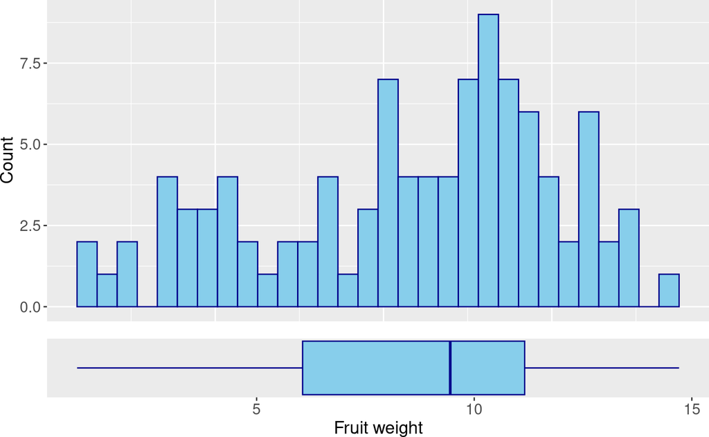

```r
# getPheno() returns a list of phenotype data.
pheno <- getPheno(object = lg)
for(i in seq_along(pheno$pheno_names)){
  p <- suppressMessages(plotPheno(object = lg,
                                  pheno = i,
                                  xlab = pheno$pheno_names[i]))
  print(p)
}
```

## 5 Conducting Association Analysis

### 5.1 Prepare a function to make a model matrix.

Association analysis can be performed using `scanAssoc()` function. Since association analysis is a type of regression analysis that requires a model formula, you need to specify one accordingly. The `scanAssoc()` function also requires a conversion function to transform the genotype data into a model matrix that fits the model formula. The `getGenoPerMarker()` function can be used to check the structure of the genotype data. If you are going to use haplotype or dosage data instead of genotype data, you can specify the `geno_format` argument as `haplotype` or `dosage`.

```r
g <- getGenoPerMarker(object = lg, geno_format = "genotype")
print(g)
```

```
##      [,1] [,2] [,3] [,4] [,5] [,6] [,7] [,8] [,9] [,10] [,11] [,12] [,13] [,14]
## [1,]    0    0    0    0    0    0    0    0    0     0     0     0     0     0
## [2,]    0    0    0    0    0    0    0    0    0     0     0     0     0     0
##      [,15] [,16] [,17] [,18] [,19] [,20] [,21] [,22] [,23] [,24] [,25] [,26]
## [1,]     0     0     0     0     0     0     0     0     0     0     0     0
## [2,]     0     0     0     0     0     0     0     0     0     0     0     0
##      [,27] [,28] [,29] [,30] [,31] [,32] [,33] [,34] [,35] [,36] [,37] [,38]
## [1,]     0     0     0     0     0     0     0     0     0     0     0     0
## [2,]     0     0     0     0     0     0     0     0     0     0     0     0
##      [,39] [,40] [,41] [,42] [,43] [,44] [,45] [,46] [,47] [,48] [,49] [,50]
## [1,]     0     0     0     0     0     0     0     0     0     0     0     0
## [2,]     0     0     0     0     0     0     0     0     0     0     0     0
##      [,51] [,52] [,53] [,54] [,55] [,56] [,57] [,58] [,59] [,60] [,61] [,62]
## [1,]     0     0     0     0     0     0     0     0     0     0     0     0
## [2,]     0     0     0     0     0     0     0     0     0     0     0     0
##      [,63] [,64] [,65] [,66] [,67] [,68] [,69] [,70] [,71] [,72] [,73] [,74]
## [1,]     0     0     0     0     0     0     0     0     0     0     0     0
## [2,]     0     0     0     0     0     0     0     0     0     0     0     0
##      [,75] [,76] [,77] [,78] [,79] [,80] [,81] [,82] [,83] [,84] [,85] [,86]
## [1,]     0     0     0     0     0     0     0     0     0     0     0     0
## [2,]     0     0     0     0     0     0     0     0     0     0     0     0
##      [,87] [,88] [,89] [,90] [,91] [,92] [,93] [,94] [,95] [,96] [,97] [,98]
## [1,]     0     0     0     0     0     0     0     0     0     0     0     0
## [2,]     0     0     0     0     0     0     0     0     0     0     0     0
##      [,99] [,100]
## [1,]     0      0
## [2,]     0      0
```

```r
g <- getGenoPerMarker(object = lg, geno_format = "haplotype")
print(g)
```

```
##      [,1] [,2] [,3] [,4] [,5] [,6] [,7] [,8] [,9] [,10] [,11] [,12] [,13] [,14]
## [1,]    2    2    2    1    1    1    2    1    2     2     1     2     2     2
## [2,]    1    2    1    2    2    2    2    2    1     2     1     2     2     1
##      [,15] [,16] [,17] [,18] [,19] [,20] [,21] [,22] [,23] [,24] [,25] [,26]
## [1,]     2     2     2     1     1     1     2     1     2     2     1     1
## [2,]     1     1     1     2     2     1     1     2     1     1     2     2
##      [,27] [,28] [,29] [,30] [,31] [,32] [,33] [,34] [,35] [,36] [,37] [,38]
## [1,]     1     2     2     2     1     2     1     1     1     2     1     1
## [2,]     1     1     2     2     1     2     2     2     1     2     1     1
##      [,39] [,40] [,41] [,42] [,43] [,44] [,45] [,46] [,47] [,48] [,49] [,50]
## [1,]     1     2     2     2     1     1     2     2     1     2     1     1
## [2,]     2     1     2     2     2     1     2     2     2     1     1     1
##      [,51] [,52] [,53] [,54] [,55] [,56] [,57] [,58] [,59] [,60] [,61] [,62]
## [1,]     1     2     2     2     1     1     1     1     1     1     2     1
## [2,]     1     1     1     2     2     2     2     1     1     2     1     1
##      [,63] [,64] [,65] [,66] [,67] [,68] [,69] [,70] [,71] [,72] [,73] [,74]
## [1,]     2     2     1     2     1     2     2     2     1     1     2     1
## [2,]     2     2     1     2     1     1     2     2     2     2     1     1
##      [,75] [,76] [,77] [,78] [,79] [,80] [,81] [,82] [,83] [,84] [,85] [,86]
## [1,]     1     2     1     2     1     2     2     1     2     1     2     1
## [2,]     2     1     2     1     2     1     1     2     1     2     2     2
##      [,87] [,88] [,89] [,90] [,91] [,92] [,93] [,94] [,95] [,96] [,97] [,98]
## [1,]     2     1     1     2     1     1     2     1     1     2     2     2
## [2,]     1     1     2     1     1     2     2     1     1     1     1     2
##      [,99] [,100]
## [1,]     1      1
## [2,]     2      1
```

```r
g <- getGenoPerMarker(object = lg, geno_format = "dosage")
print(g)
```

```
##   [1] 1 2 1 1 1 1 2 1 1 2 0 2 2 1 1 1 1 1 1 0 1 1 1 1 1 1 0 1 2 2 0 2 1 1 0 2 0
##  [38] 0 1 1 2 2 1 0 2 2 1 1 0 0 0 1 1 2 1 1 1 0 0 1 1 0 2 2 0 2 0 1 2 2 1 1 1 0
##  [75] 1 1 1 1 1 1 1 1 1 1 2 1 1 0 1 1 0 1 2 0 0 1 1 2 1 0
```

As shown above, genotype and haplotype data for each marker is a matrix with two rows if you have diploid samples, whereas dosage data is a vector. You need to prepare a function to convert those data into a model matrix for the regression analysis.

When you use the dosage data as input for the regression analysis, the conversion function can be defined manually as shown below.

```r
# Conversion function for dosage data assuming additive and dominant effects
conv_fun <- function(g){
  add <- g
  dom <- as.numeric(g == 1)
  out <- data.frame(add = add, dom = dom)
  return(out)
}

# For the model matrix above, the formula can be the following.
formula <- "add + dom"
```

Since genotype data indicates reference and alternative alleles as 0 and 1, you can sum the genotype values to obtain the number of alternative alleles. If the reference allele consistently represents the reference haplotype — for example, when 0 and 1 in the genotype data always represent alleles inherited from Parent 1 and Parent 2, respectively — the number of alternative alleles can be treated as the dosage of alternative haplotypes.

```r
conv_fun <- function(g){
  add <- colSums(g)
  dom <- as.numeric(g == 1)
  out <- data.frame(add = add, dom = dom)
  return(out)
}

# For the model matrix above, the formula can be the following.
formula <- "add + dom"
```

For the haplotype data, you can incorporate interaction effects of haplotypes as follows.

```r
# Conversion function for haplotype data assuming additive and interaction effects
conv_fun <- function(g){
  hap1 <- colSums(g == 1)
  hap2 <- colSums(g == 2)
  hap1_hap2 <- as.numeric(hap1 == 1 & hap2 == 1)
  out <- data.frame(hap2 = hap2, hap1_hap2 = hap1_hap2)
  return(out)
}
formula <- "hap2 + hap1_hap2"
```

Although you can manually define a function for the data conversion, the makeConvFun() function helps you create a data conversion function.

```r
# The n_levels argument specifies the number of dosage levels.
# For diploid samples, n_levels should be set to 3: 0, 1, and 2 represent
# null-, single-, and duplex dosages, respectively.
conv_fun <- makeConvFun(geno_format = "dosage", n_levels = 3)
```

```
## Use the following formula:
## add + dom
```

```r
formula <- "add + dom"
```

You can check the conversion function definition

```r
conv_fun
```

```
## function(g){
##       add <- g
##       dom <- as.numeric(g == 1)
##       out <- data.frame(add = add, dom = dom)
##       return(out)
##     }
## <bytecode: 0x55e9202569b8>
## <environment: 0x55e92023e468>
```

The current implementation of the `makeConvFun()` function does not support to assume interaction effects of haplotypes. If necessary, please define a conversion function manually as shown in the previous code chunk. When you have four haplotypes, the function definition can be the following.

```r
# Do not run.
conv_fun <- function(g){
  hap1 <- colSums(g == 1)
  hap2 <- colSums(g == 2)
  hap3 <- colSums(g == 3)
  hap4 <- colSums(g == 4)
  hap1_hap2 <- as.numeric(hap1 == 1 & hap2 == 1)
  hap1_hap3 <- as.numeric(hap1 == 1 & hap3 == 1)
  hap1_hap4 <- as.numeric(hap1 == 1 & hap4 == 1)
  hap2_hap3 <- as.numeric(hap2 == 1 & hap3 == 1)
  hap2_hap4 <- as.numeric(hap2 == 1 & hap4 == 1)
  hap3_hap4 <- as.numeric(hap3 == 1 & hap4 == 1)
  out <- data.frame(hap2 = hap2, hap3 = hap3, hap4 = hap4,
                    hap1_hap2 = hap1_hap2, hap1_hap3 = hap1_hap3,
                    hap1_hap4 = hap1_hap4, hap2_hap3 = hap2_hap3,
                    hap2_hap4 = hap2_hap4, hap3_hap4 = hap3_hap4)
  return(out)
}
formula <- paste0("hap2 + hap3 + hap4 + hap1_hap2 + hap1_hap3",
                  " + hap1_hap4 + hap2_hap3 + hap2_hap4 + hap3_hap4")
```

### 5.2 Association Analysis

The `scanAssoc()` function performs regression analysis using a model formula specified via the `formula` argument and a model matrix generated by a conversion function provided through the `conv_fun` argument, which is applied to the data specified by the `geno_format` argument. In the following case, dosage data is used when `geno_format = "dosage"` is specified.

```r
scanAssoc(object = lg,
          formula = formula,
          conv_fun = conv_fun,
          geno_format = "dosage")
```

```
## Going to analyze the following phenotypes:
## Fruit weight
```

```
## Processing:
## Fruit weight
```

For GWAS, set `method = "mlm"`. When `method = "mlm"` is specified, only `geno_format = "genotype"` or `geno_format = "corrected"` is accepted. If `geno_format = "corrected"` is specified, corrected genotype data generated by *GBScleanR* will be used for regression analysis.

```r
scanAssoc(object = lg,
          geno_format = "genotype",
          method = "mlm")
```

If you conducted association tests using another tool and have p values, you can assign those p values to the `LazyGas` class object. In this case, you also need to specify `geno_format`, `conv_fun`, and `formula` as they will be used in the later steps. A phenotype name should be specified via the `pheno_name` argument. When you have multiple phenotypes, you can assign p values by repeating the `assignPvalues()` function for each phenotype.

```r
# As an example, extract p values from the LazyGas object and assign them to the object again.
scan <- lazyData(object = lg, dataset = "scan", pheno = "Fruit weight")
lg <- assignPvalues(object = lg, pheno_name = "Fruit weight",
                    p_values = scan$P.model,
                    geno_format = "dosage", conv_fun = conv_fun,
                    formula = formula)
```

## 6 Visualizing Results

Generate Manhattan plots for association results.

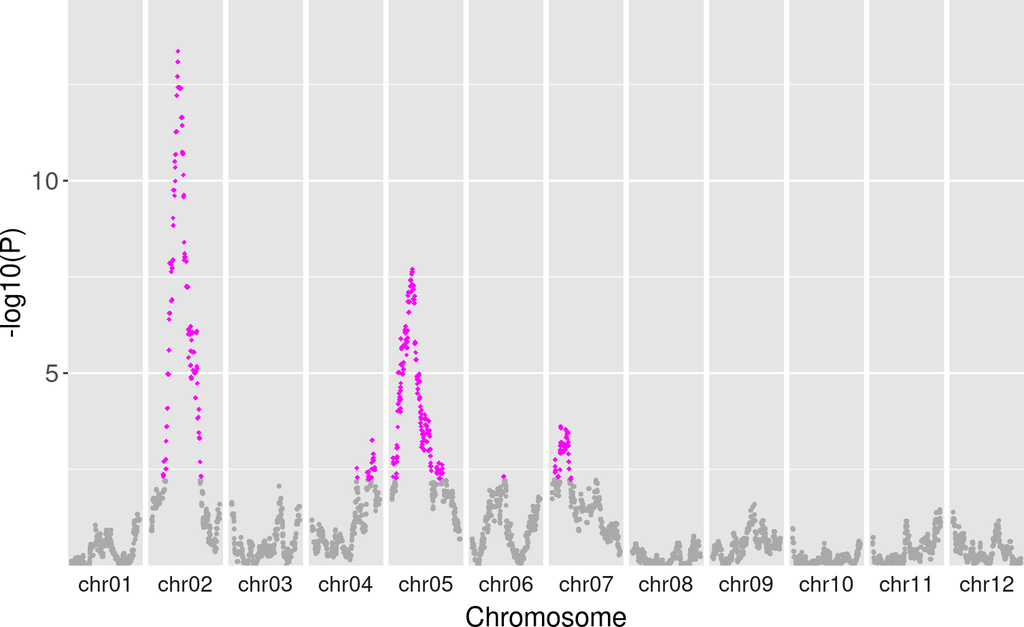

```r
pheno <- getPheno(object = lg)
for(i in seq_along(pheno$pheno_names)){
  p <- plotManhattan(object = lg, pheno = i)
  print(p)
}
```

```r
# lazyData() function can be used to extract the results.
scan <- lazyData(object = lg, dataset = "scan", pheno = pheno$pheno_names[1])
scan[which.max(scan$negLog10P), ]
```

```
##      variant_ID   Chr      Pos      P.model          FDR negLog10P
## 1378       1378 chr02 13920070 4.312875e-14 9.825493e-11  13.36523
```

The `callPeakBlock()` function defines peaks based on adjusted p-values (FDR) obtained from association analysis at markers, as well as genotype correlations between markers — in other words, linkage disequilibrium.

```r
callPeakBlock(object = lg, signif = 0.05, threshold = 0.8)
```

The peaks detected by the `callPeakBlock()` function can be visualized using the `plotPeaks()` function.

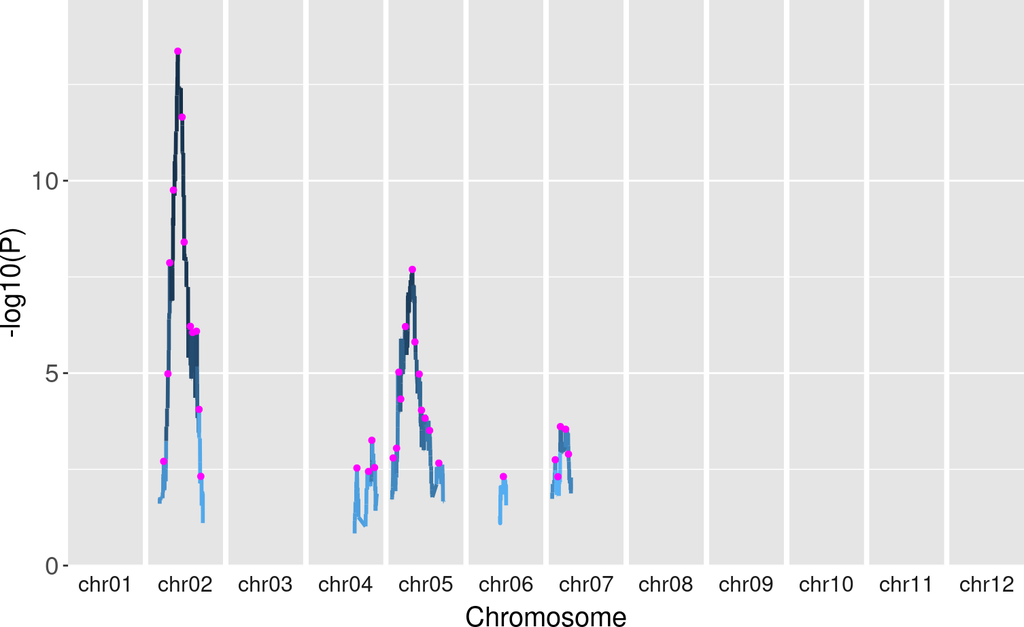

```r
for(i in seq_along(pheno$pheno_names)){
  p <- plotPeaks(object = lg, pheno = i)
  print(p)
}
```

## 7 Recalculating and Visualizing Peaks

As shown in the peak plot above, visual inspection may reveal many small peak regions detected within a larger peak region, which might be considered a single peak. To group these small peaks into a single peak, you can use the `recalcAssoc()` function. This function tests the independence of peaks based on multiple regression analysis. In the multiple regression model, all possible pairs of peaks are selected from the detected peaks, and each combination is tested to assess their independence by comparing the model fit of a full model — which includes both selected peaks as variables — and a reduced model that includes only one of the peaks. If the full model is preferred over the reduced model at a p-value threshold (the default is 0.05), the two peaks are considered independent. Otherwise, the higher peak (the one with the greater -log10(P) value) is retained, and the other is removed and recorded as grouped with the higher peak under the `groups` node in the GDS file.

The refine_position argument specifies whether to recalculate the p-values of markers around each peak using multiple regression models, treating peaks other than the one under test as fixed-effect variables. This process may result in changes to the original peak positions defined by `callPeakBlock()`. The `grouping_threshold` argument specifies the threshold for grouping peaks. The default is 0.05.

```r
recalcAssoc(object = lg,
            n_threads = 10,
            refine_position = FALSE,
            grouping_threshold = 0.05)
```

```
## Processing: Fruit weight
```

```
## Grouping associations...
```

The recalculated peaks can be visualized using the `plotPeaks()` function with `recal = TRUE`.

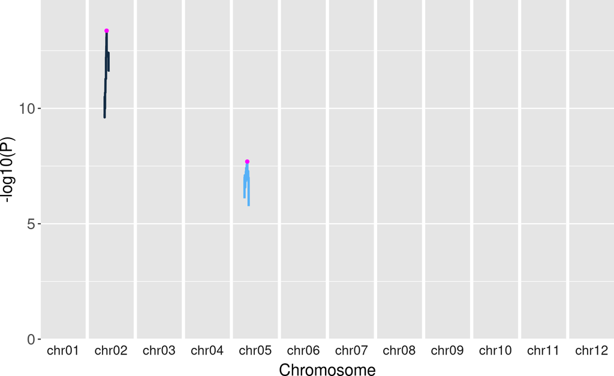

```r
for(i in seq_along(pheno$pheno_names)){
  p <- plotPeaks(object = lg, pheno = i, recalc = TRUE)
  print(p)
}
```

## 8 Visualizing Haplotype and Phenotype Data

You can generate haplotype-wise phenotype distribution plots using the `haploPlot()` function for peaks both before and after applying `recalcAssoc()`.

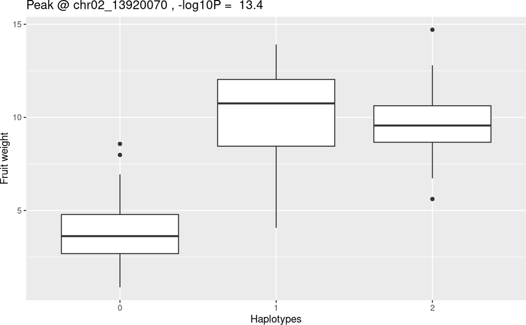

```r
for(i in seq_along(pheno$pheno_names)){
  out <- haploPlot(object = lg, pheno = i, recalc = FALSE)
  # As the output is a list of ggplot objects, only the first plot is shown here.
  print(out[[1]])
}
```

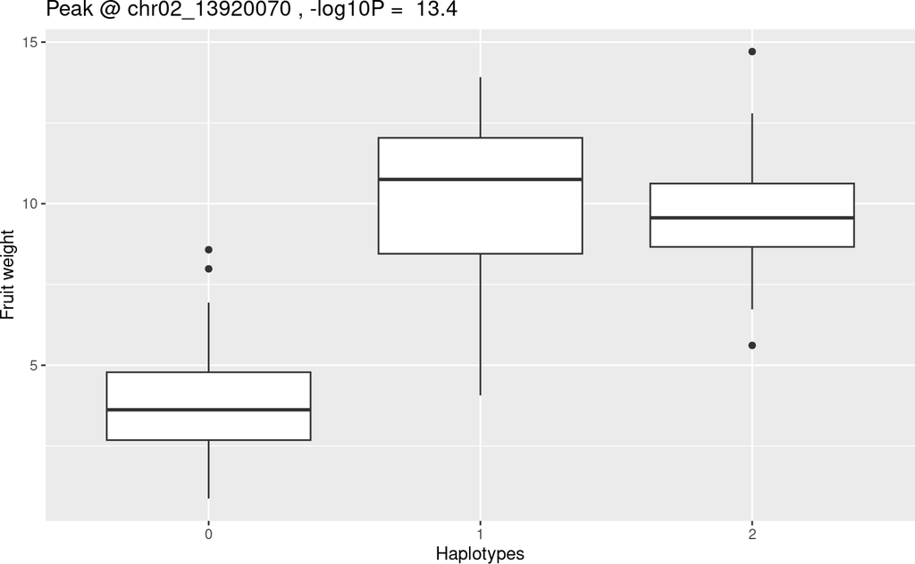

```r
for(i in seq_along(pheno$pheno_names)){
  out <- haploPlot(object = lg, pheno = i, recalc = TRUE)
  # As the output is a list of ggplot objects, only the first plot is shown here.
  print(out[[1]])
}
```

## 9 List up candidate genes

The `listCandidate()` function helps you list candidate genes for the detected association peaks. You are required to provide a GFF file containing gene annotations. If you have a VCF file output from SnpEff, you can also provide it to the function to summarize variant impacts on gene functions. Since a VCF file output from SnpEff is large and takes a long time to load into the R environment, the `snpeff2gds()` function allows you to convert the VCF file into a GDS file. The converted GDS file must then be provided to the `listCandidate()` function after opening a connection to the file using the `open_snpeff()` function, as shown below. In addition, a data.frame containing other gene annotations can be provided to the `listCandidate()` function to include that information in the output candidate list. The data.frame must contain a column named “GeneID”, which should match the gene IDs in the GFF file.

```r
# Do not run.
# GFF file
gff_fn <- "path/to/gff/gene_annotation.gff"
gff <- rtracklayer::import.gff(gff_fn)

# SnpEff output VCF file
snpeff_fn <- "path/to/SnpEff/output/variants.snpeff.vcf"
gds_fn <- sub("\\.vcf", ".gds", snpeff_fn)
snpeff2gds(vcf_fn = snpeff_fn, out_fn = gds_fn)
snpeff_gds <- open_snpeff(gds_fn = gds_fn)

# Any CSV format file for gene annotations
# The given matrix stored in the CSV file must contain a column named "GeneID"
# that should match the gene IDs in the GFF file.
ann <- read.csv("~/01_wd/genomeData/rice/cultivar_sativa/nb_combined/version_2023/gff/nb_combined_summarized_annotation.tsv")
names(ann)[1] <- "Gene_ID"
listCandidate(object = lg, gff = gff, snpeff = snpeff_gds, ann = ann, recalc = TRUE)
```

## 10 Extracting Data

The phenotype data assigned to a `LazyGas` class object, along with the output data generated by functions in the `lazyGas` package, can be retrieved using the `lazyData()` function.

```r
pheno <- getPheno(object = lg)
sapply(pheno, head)
```

```
## $pheno
##   Fruit weight
## 1     4.827929
## 2     8.234601
## 3    10.535603
## 4     4.056910
## 5     9.097794
## 6    11.680488
##
## $pheno_type
##              binary    normality
## Fruit weight  FALSE 0.0007573401
##
## $pheno_names
## [1] "Fruit weight"
```

The output of association analysis.

```r
scan <- lazyData(object = lg, dataset = "scan", pheno = pheno$pheno_names[1])
head(scan)
```

```
##   variant_ID   Chr    Pos   P.model       FDR  negLog10P
## 1          1 chr01  14117 0.7596431 0.9111959 0.11939041
## 2          2 chr01  46350 0.7699854 0.9179242 0.11351749
## 3          3 chr01  60280 0.7699854 0.9179242 0.11351749
## 4          4 chr01  66707 0.8472064 0.9550471 0.07201079
## 5          5 chr01 116542 0.8472064 0.9550471 0.07201079
## 6          6 chr01 128195 0.8472064 0.9550471 0.07201079
```

The output of peak calling.

```r
peakcall <- lazyData(object = lg, dataset = "peakcall", pheno = pheno$pheno_names[1])
head(peakcall)
```

```
##   peak_ID peak_variant_ID peak_Chr peak_Pos peak_negLog10P variant_ID dist2peak
## 1       1            1378    chr02 13920070       13.36523       1335  -1790181
## 2       1            1378    chr02 13920070       13.36523       1336  -1762077
## 3       1            1378    chr02 13920070       13.36523       1337  -1733283
## 4       1            1378    chr02 13920070       13.36523       1338  -1720113
## 5       1            1378    chr02 13920070       13.36523       1339  -1683743
## 6       1            1378    chr02 13920070       13.36523       1340  -1583205
##     LD2peak chr_start chr_end   Chr      Pos          FDR negLog10P
## 1 0.7882074         0       0 chr02 12129889 1.696601e-08   9.75618
## 2 0.8035243         0       0 chr02 12157993 2.264271e-08   9.61031
## 3 0.8035243         0       0 chr02 12186787 2.264271e-08   9.61031
## 4 0.8197252         0       0 chr02 12199957 3.388228e-09  10.50389
## 5 0.8197252         0       0 chr02 12236327 3.388228e-09  10.50389
## 6 0.8197252         0       0 chr02 12336865 3.388228e-09  10.50389
```

The output of peak calling after peak grouping.

```r
recalc <- lazyData(object = lg, dataset = "recalc", pheno = pheno$pheno_names[1])
head(recalc)
```

```
##   peak_ID peak_variant_ID peak_Chr peak_Pos peak_negLog10P variant_ID dist2peak
## 1       1            1378    chr02 13920070       13.36523       1335  -1790181
## 2       1            1378    chr02 13920070       13.36523       1336  -1762077
## 3       1            1378    chr02 13920070       13.36523       1337  -1733283
## 4       1            1378    chr02 13920070       13.36523       1338  -1720113
## 5       1            1378    chr02 13920070       13.36523       1339  -1683743
## 6       1            1378    chr02 13920070       13.36523       1340  -1583205
##     LD2peak chr_start chr_end          FDR negLog10P   Chr      Pos
## 1 0.7882074         0       0 1.696601e-08   9.75618 chr02 12129889
## 2 0.8035243         0       0 2.264271e-08   9.61031 chr02 12157993
## 3 0.8035243         0       0 2.264271e-08   9.61031 chr02 12186787
## 4 0.8197252         0       0 3.388228e-09  10.50389 chr02 12199957
## 5 0.8197252         0       0 3.388228e-09  10.50389 chr02 12236327
## 6 0.8197252         0       0 3.388228e-09  10.50389 chr02 12336865
```

The record of peak grouping.

```r
groups <- lazyData(object = lg, dataset = "groups", pheno = pheno$pheno_names[1])
head(groups)
```

```
##      peak_ID variant_ID          FDR negLog10P grouped_with
## [1,]       1       1378 9.825493e-11 13.365233         1378
## [2,]       2       1429 4.003284e-10 11.652843         1378
## [3,]       3       1326 1.696601e-08  9.756180         1378
## [4,]       3       1378 9.825493e-11 13.365233         1378
## [5,]       4       1466 3.191635e-07  8.404906         1378
## [6,]       5       1262 8.402021e-07  7.867349         1378
##      full_vs_reduce_pvalue
## [1,]                    NA
## [2,]             0.5860422
## [3,]             0.2884251
## [4,]                    NA
## [5,]             0.6610248
## [6,]             0.7168801
```

The list of candidate genes.

```r
# Do not run.
candidate <- lazyData(object = lg, dataset = "candidate", pheno = pheno$pheno_names[1])
head(candidate)
```

The gene-wise summarized SnpEff annotation.

```r
# Do not run.
candidate <- lazyData(object = lg, dataset = "snpeff", pheno = pheno$pheno_names[1])
head(candidate)
```

## 11 Generating Interactive HTML Report

To organize the results of the analysis, you can generate an interactive HTML. The `what` argument accepts a character vector specifying one or more types of plots to generate. Users can choose from the following options: - `"scan"`: Draws an **interactive Manhattan plot**.  
- `"scan_png"`: Draws a **static Manhattan plot**.  
- `"peakcall"`: Draws an **interactive peak call plot**.  
- `"recalc"`: Draws an **interactive recalculated peak call plot**.  
- `"groups"`: Draws an **interactive peak grouping list**.  
- `"peakcall_haplo"`: Draws an **interactive haplotype-wise phenotype distribution plot** for peaks **before recalculation**.  
- `"recalc_haplo"`: Draws an **interactive haplotype-wise phenotype distribution plot** for peaks **after recalculation**.  
- `"candidate"`: Draws an **interactive list of candidate genes**.

```r
# Do not run.
# Which phenotype should be used for the interactive HTML report is specified
# via `pheno` argument.
makeInteractiveSummary(object = lg,
                       pheno = pheno$pheno_names[1],
                       out_fn = "sample.html",
                       what = c("scan", "scan_png",
                                "peakcall", "recalc", "groups",
                                "preakcall_haplo", "recalc_haplo",
                                "candidate"))
```